# Customer_Churn

Siva Bulusu

October 9, 2019

## Problem

Build a logistic regression model and interpret the results to predict customer churn using given dataset containing cellphone usage details.

## Solution

“Dataset_Cellphone.xlsx” is the excel file which contains required data. “Data” sheet contains required information to predict the customer churn.

Include required libraries

```r
library(readxl)
library(DataExplorer)
```

```r
library(corrplot)
library(caTools)
library(caret)
library(lmtest)
library(pscl)
library(Deducer)
library(PerformanceAnalytics)
```

Set working directory and check.

```r
setwd("D:/SivaBulusu/CustomerChurnPrediction")
getwd()
```

```
## [1] "D:/SivaBulusu/CustomerChurnPrediction"
```

Read data from excel file and view it to verify.

```r
ChurnData <- read_excel("Dataset_Cellphone.xlsx", sheet = "Data")
ChurnData
```

```
## # A tibble: 3,333 x 11
##    Churn AccountWeeks ContractRenewal DataPlan DataUsage CustServCalls
##    <dbl>        <dbl>           <dbl>    <dbl>     <dbl>         <dbl>
##  1     0          128               1        1      2.7              1
##  2     0          107               1        1      3.7              1
##  3     0          137               1        0      0                0
##  4     0           84               0        0      0                2
##  5     0           75               0        0      0                3
##  6     0          118               0        0      0                0
##  7     0          121               1        1      2.03             3
##  8     0          147               0        0      0                0
##  9     0          117               1        0      0.19             1
## 10     0          141               0        1      3.02             0
## # ... with 3,323 more rows, and 5 more variables: DayMins <dbl>,
## #   DayCalls <dbl>, MonthlyCharge <dbl>, OverageFee <dbl>, RoamMins <dbl>
```

```r
View(ChurnData)
```

Check the data summary and understand the data.

```r
dim(ChurnData)
```

```
## [1] 3333   11
```

```r
str(ChurnData)
```

```
## Classes 'tbl_df', 'tbl' and 'data.frame':    3333 obs. of  11 variables:
##  $ Churn          : num  0 0 0 0 0 0 0 0 0 0 ...
##  $ AccountWeeks   : num  128 107 137 84 75 118 121 147 117 141 ...
##  $ ContractRenewal: num  1 1 1 0 0 0 1 0 1 0 ...
##  $ DataPlan       : num  1 1 0 0 0 0 1 0 0 1 ...
##  $ DataUsage      : num  2.7 3.7 0 0 0 0 2.03 0 0.19 3.02 ...
##  $ CustServCalls  : num  1 1 0 2 3 0 3 0 1 0 ...
##  $ DayMins        : num  265 162 243 299 167 ...
##  $ DayCalls       : num  110 123 114 71 113 98 88 79 97 84 ...
##  $ MonthlyCharge  : num  89 82 52 57 41 57 87.3 36 63.9 93.2 ...
##  $ OverageFee     : num  9.87 9.78 6.06 3.1 7.42 ...
##  $ RoamMins       : num  10 13.7 12.2 6.6 10.1 6.3 7.5 7.1 8.7 11.2 ...
```

```r
summary(ChurnData)
```

```
##      Churn         AccountWeeks   ContractRenewal     DataPlan
##  Min.   :0.0000   Min.   :  1.0   Min.   :0.0000   Min.   :0.0000
##  1st Qu.:0.0000   1st Qu.: 74.0   1st Qu.:1.0000   1st Qu.:0.0000
##  Median :0.0000   Median :101.0   Median :1.0000   Median :0.0000
##  Mean   :0.1449   Mean   :101.1   Mean   :0.9031   Mean   :0.2766
##  3rd Qu.:0.0000   3rd Qu.:127.0   3rd Qu.:1.0000   3rd Qu.:1.0000
##  Max.   :1.0000   Max.   :243.0   Max.   :1.0000   Max.   :1.0000
##    DataUsage      CustServCalls      DayMins         DayCalls
##  Min.   :0.0000   Min.   :0.000   Min.   :  0.0   Min.   :  0.0
##  1st Qu.:0.0000   1st Qu.:1.000   1st Qu.:143.7   1st Qu.: 87.0
##  Median :0.0000   Median :1.000   Median :179.4   Median :101.0
##  Mean   :0.8165   Mean   :1.563   Mean   :179.8   Mean   :100.4
##  3rd Qu.:1.7800   3rd Qu.:2.000   3rd Qu.:216.4   3rd Qu.:114.0
##  Max.   :5.4000   Max.   :9.000   Max.   :350.8   Max.   :165.0
##  MonthlyCharge      OverageFee       RoamMins
##  Min.   : 14.00   Min.   : 0.00   Min.   : 0.00
##  1st Qu.: 45.00   1st Qu.: 8.33   1st Qu.: 8.50
##  Median : 53.50   Median :10.07   Median :10.30
##  Mean   : 56.31   Mean   :10.05   Mean   :10.24
##  3rd Qu.: 66.20   3rd Qu.:11.77   3rd Qu.:12.10
##  Max.   :111.30   Max.   :18.19   Max.   :20.00
```

There are 11 columns and 3333 rows in the given dataset.

Check for missing values in the dataset.

```r
sapply(ChurnData,function(x){sum(is.na(x))})
```

```
##           Churn    AccountWeeks ContractRenewal        DataPlan
##               0               0               0               0
##       DataUsage   CustServCalls         DayMins        DayCalls
##               0               0               0               0
##   MonthlyCharge      OverageFee        RoamMins
##               0               0               0
```

There are no missing values in the given dataset. No more treatment is required regarding.

Check for churned customers in the given dataset.

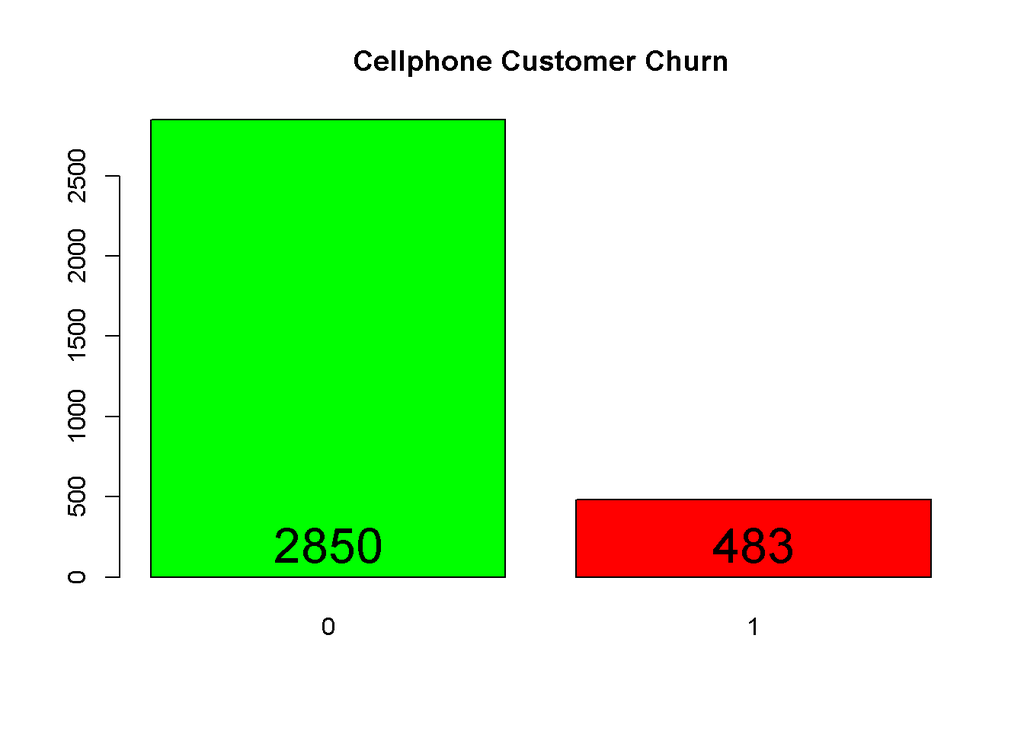

```r
#Find out the total number of churned customers in the given dataset for better understanding.
text(barplot(table(ChurnData$Churn),col=c('green','red'),main='Cellphone Customer Churn')
     ,0,table(ChurnData$Churn),cex=2,pos=3)
```

483(14.49%) customers have churned out. 2850(85.5%) customers are loyal.

Check for correlations in the given dataset.

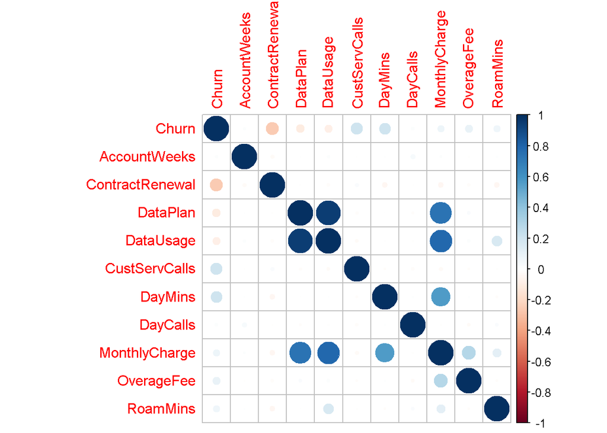

```r
corelChurn<-cor(ChurnData[sapply(ChurnData, is.numeric)])#cor(ChurnData)
corrplot(corelChurn,method ="circle")
```

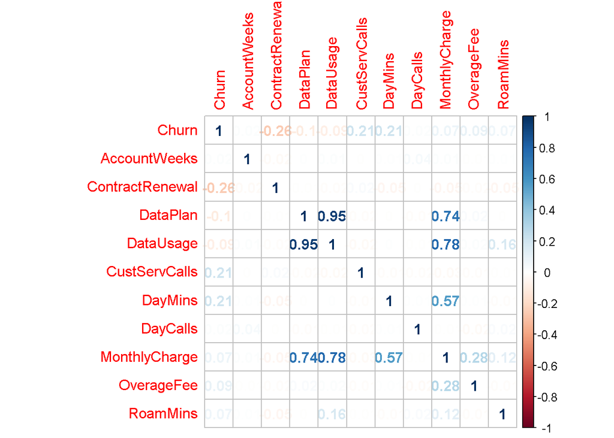

```r
corrplot(corelChurn,method ="number")
```

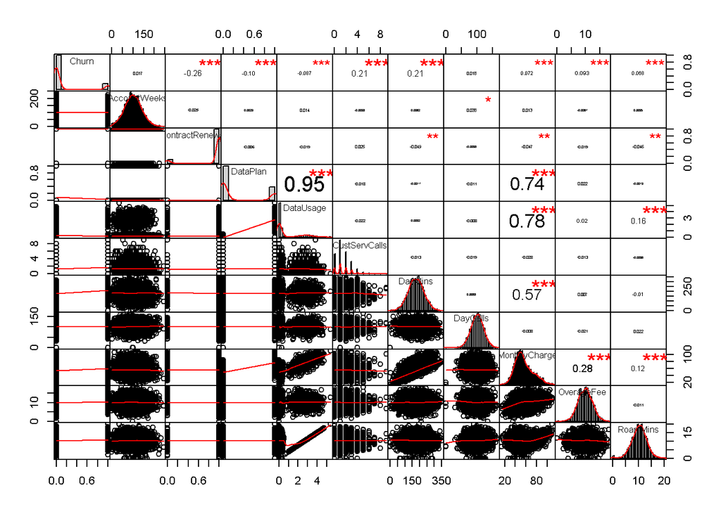

```r
chart.Correlation(ChurnData, histogram=TRUE, pch=19)
```

Churn has negative correlation with ContractRenewal, DataPlan, DataUsage. Churn has positive correlation with CustServCalls, DayMins, MonthlyCharge, OverageFee, RoamMins.

Partition the data in to train.df (70%) for training the model and test.df (30%) for validating the results.

```r
set.seed(100)
index    <- createDataPartition(ChurnData$Churn, p = 0.7, list = FALSE)
train.df <- ChurnData[index, ]
test.df  <- ChurnData[-index, ]
```

Check if the data has been split as expected.

```r
dim(train.df)
```

```
## [1] 2334   11
```

```r
dim(test.df)
```

```
## [1] 999  11
```

Train dataset has 70% (2334/3333) of total data. Test dataset has 30% (999/3333) of total data. So the given dataset has been split as desired.

Check proportion of churn in the training, test and given datasets.

```r
#Check proportion of churn in the training dataset
table(train.df$Churn)
```

```
##
##    0    1
## 2011  323
```

```r
#Check proportion of churn in the testing dataset
table(test.df$Churn)
```

```
##
##   0   1
## 839 160
```

```r
#Check proportion of churn in the given dataset
table(ChurnData$Churn)
```

```
##
##    0    1
## 2850  483
```

Build logistic regression model and check the summary.

```r
logistic.model <- glm(train.df$Churn~., data = train.df, family = binomial(link = 'logit'))
summary(logistic.model)
```

```
##
## Call:
## glm(formula = train.df$Churn ~ ., family = binomial(link = "logit"),
##     data = train.df)
##
## Deviance Residuals:
##     Min       1Q   Median       3Q      Max
## -1.9531  -0.4952  -0.3341  -0.2033   3.0224
##
## Coefficients:
##                   Estimate Std. Error z value Pr(>|z|)
## (Intercept)     -5.8650777  0.6552801  -8.950  < 2e-16 ***
## AccountWeeks     0.0008389  0.0016999   0.494 0.621659
## ContractRenewal -2.0460108  0.1739239 -11.764  < 2e-16 ***
## DataPlan        -0.6298790  0.6471339  -0.973 0.330386
## DataUsage       -0.4345829  2.3436267  -0.185 0.852890
## CustServCalls    0.5180735  0.0470399  11.013  < 2e-16 ***
## DayMins          0.0073521  0.0396065   0.186 0.852735
## DayCalls        -0.0002487  0.0033145  -0.075 0.940197
## MonthlyCharge    0.0330801  0.2326242   0.142 0.886919
## OverageFee       0.0871253  0.3957986   0.220 0.825773
## RoamMins         0.0917040  0.0268177   3.420 0.000627 ***
## ---
## Signif. codes:  0 '***' 0.001 '**' 0.01 '*' 0.05 '.' 0.1 ' ' 1
##
## (Dispersion parameter for binomial family taken to be 1)
##
##     Null deviance: 1876.7  on 2333  degrees of freedom
## Residual deviance: 1471.7  on 2323  degrees of freedom
## AIC: 1493.7
##
## Number of Fisher Scoring iterations: 6
```

ContractRenewal, CustServCalls, RoamMins seem to be more significant for customer churn.

Predict churn probabilities with above model. Predict churn by converting value to 1 if it is greater than 0.5. Else put 0 as value.

```r
#Predict churn probabilities with above model
log.pred <- predict(logistic.model, newdata = test.df, type = 'response')
log.pred
```

[output not shown]

[output cut: 279 more lines]

[output not shown]

```r
write.csv(log.pred,"ChurnProbabilities.csv")

#Convert probabilities to binary to predict churn
log.pred <- as.factor(ifelse(log.pred > 0.5, 1, 0))
log.pred
```

[output not shown]

[output cut: 98 more lines]

```r
test.df["Predicted Churn"] <- log.pred
test.df
```

```
## # A tibble: 999 x 12
##    Churn AccountWeeks ContractRenewal DataPlan DataUsage CustServCalls
##    <dbl>        <dbl>           <dbl>    <dbl>     <dbl>         <dbl>
##  1     0          128               1        1      2.7              1
##  2     0          137               1        0      0                0
##  3     0          121               1        1      2.03             3
##  4     0           76               1        1      2.7              1
##  5     0          147               1        0      0.31             0
##  6     0           54               1        0      0                3
##  7     0           57               1        1      2.24             0
##  8     0           36               1        1      3.92             0
##  9     0          136               0        1      2.84             3
## 10     0           98               1        0      0.3              3
## # ... with 989 more rows, and 6 more variables: DayMins <dbl>,
## #   DayCalls <dbl>, MonthlyCharge <dbl>, OverageFee <dbl>, RoamMins <dbl>,
## #   `Predicted Churn` <fct>
```

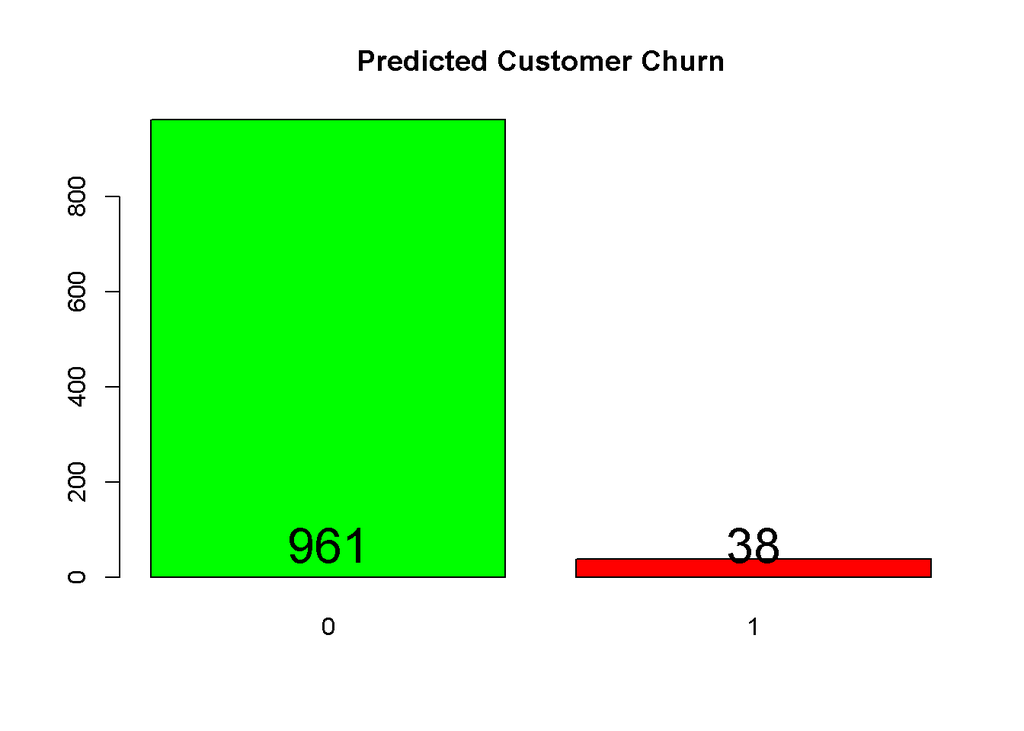

```r
write.csv(test.df,"ChurnPredictions.csv")

#Find out the total number of churned customers in the testing dataset for better understanding.
text(barplot(table(log.pred),col=c('green','red'),main='Predicted Customer Churn')
     ,0,table(log.pred),cex=2,pos=3)
```

There are 38 customers that are going to churn as per prediction. This is around 4% of the testing dataset. “ChurnProbabilities.csv” has the probabilities for churn. “ChurnPredictions.csv” has the churn predictions related to the testing dataset. Predicted values are added under ‘Predicted Churn’ column in this file. Both the files are uploaded in the portal for reference.

Evaluate Metrics for the Logistic Regression Model built.

```r
#Convert Churn column as factor
test.df$Churn <- as.factor(test.df$Churn)

# Evaluation Metrics
#Confusion matrix
confmatrix    <- confusionMatrix(data = log.pred, test.df$Churn)
confmatrix
```

```
## Confusion Matrix and Statistics
##
##           Reference
## Prediction   0   1
##          0 821 140
##          1  18  20
##
##                Accuracy : 0.8418
##                  95% CI : (0.8177, 0.8639)
##     No Information Rate : 0.8398
##     P-Value [Acc > NIR] : 0.4523
##
##                   Kappa : 0.1498
##  Mcnemar's Test P-Value : <2e-16
##
##             Sensitivity : 0.9785
##             Specificity : 0.1250
##          Pos Pred Value : 0.8543
##          Neg Pred Value : 0.5263
##              Prevalence : 0.8398
##          Detection Rate : 0.8218
##    Detection Prevalence : 0.9620
##       Balanced Accuracy : 0.5518
##
##        'Positive' Class : 0
##
```

Total customers in the test dataset is 999. TP + TN + FP + FN = 999

True Positives: 20 means there are 20 customers who are going to leave and they are predicted by our model correctly.

True Negatives: 821 means there are 821 customers who are going to stay and they are predicted correctly.

False Positives: 18 means there are 18 customers who are predicted as churn category but they are not really going to leave. This is Type 1 Error. Consequence would be these customers will be given more priority assuming that they might leave. But really, they don’t need that much attention.

False Negatives: 140 means there are 140 customers who are predicted as they are going to stay but actually, they are going to leave. This is Type 2 Error. It is critical as these customers when not given proper attention and neglected can mostly leave. Firm will miss a chance to take measures to retain these 140 customers as they are not in the positive category for churn.

All the above values of TP, TN, FP, FN are matching with values in “ChurnPredictions.csv” which was generated in above steps.

Find precision, recall and F1.

```r
#Precision
precision <- confmatrix$byClass['Pos Pred Value']
precision
```

```
## Pos Pred Value
##      0.8543184
```

```r
#Recall
recall    <- confmatrix$byClass['Sensitivity']
recall
```

```
## Sensitivity
##   0.9785459
```

```r
#F1
F1        <- confmatrix$byClass['F1']
F1
```

```
##        F1
## 0.9122222
```

Check odds ratio for the model. Extract model coefficients.

```r
#odds ratio - Extract Model Coefficients
odds<-exp(coef(logistic.model))
exp(coef(logistic.model))
```

```
##     (Intercept)    AccountWeeks ContractRenewal        DataPlan
##     0.002836803     1.000839266     0.129249474     0.532656242
##       DataUsage   CustServCalls         DayMins        DayCalls
##     0.647534666     1.678790407     1.007379237     0.999751367
##   MonthlyCharge      OverageFee        RoamMins
##     1.033633337     1.091033414     1.096040396
```

```r
write.csv(odds,"Churnodds.csv")
```

“Churnodds.csv” has the churn odds related to the logistic regression model. The file is uploaded in the portal for reference. The same is shared above for quick view.

Check confidence Intervals for model parameters.

```r
exp(confint(logistic.model))
```

```
##                        2.5 %      97.5 %
## (Intercept)     0.0007714509  0.01008217
## AccountWeeks    0.9975093856  1.00418316
## ContractRenewal 0.0917991127  0.18165200
## DataPlan        0.1460137566  1.85281112
## DataUsage       0.0065220478 64.14024719
## CustServCalls   1.5319882872  1.84256336
## DayMins         0.9321047660  1.08878194
## DayCalls        0.9932829095  1.00628029
## MonthlyCharge   0.6549928553  1.63136060
## OverageFee      0.5020650207  2.37174009
## RoamMins        1.0403782926  1.15578712
```

Check Pseudo R Square values.

```r
lrtest(logistic.model)
```

```
## Likelihood ratio test
##
## Model 1: train.df$Churn ~ AccountWeeks + ContractRenewal + DataPlan +
##     DataUsage + CustServCalls + DayMins + DayCalls + MonthlyCharge +
##     OverageFee + RoamMins
## Model 2: train.df$Churn ~ 1
##   #Df  LogLik  Df  Chisq Pr(>Chisq)
## 1  11 -735.84
## 2   1 -938.33 -10 404.99  < 2.2e-16 ***
## ---
## Signif. codes:  0 '***' 0.001 '**' 0.01 '*' 0.05 '.' 0.1 ' ' 1
```

```r
pR2(logistic.model)
```

```
##          llh      llhNull           G2     McFadden         r2ML
## -735.8376615 -938.3340480  404.9927729    0.2158042    0.1592986
##         r2CU
##    0.2883285
```

McFadden Pseudo R Squared value of 0.216(approx.) indicates that churn prediction is explained by 21% in this model. McFadden values between 0.2 to 0.4 are very good. So our model is good enough as per the numbers.

Check Area under curve for the model using rocplot function.

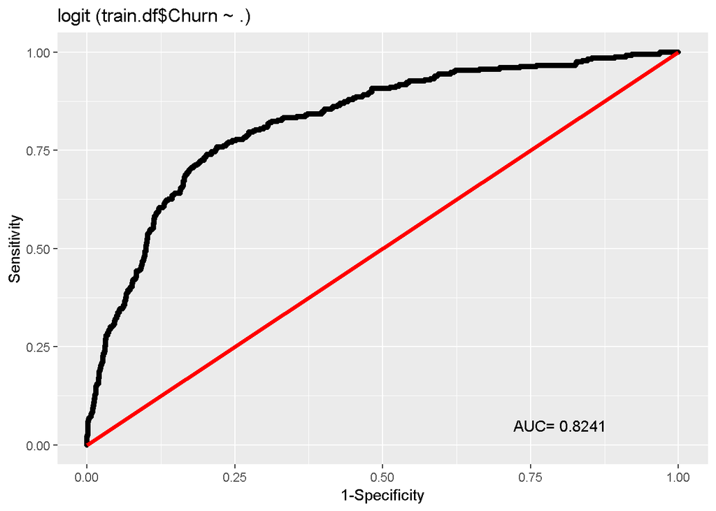

```r
rocplot(logistic.model)
```

The AUC value that indicates area under the curve is 82.41% for this model which is really a good value. This indicates that our model is good.